# Correcting for age in differential expression analysis

RAPToR 1.2.0

Romain Bulteau

March 2023

# 1 Introduction

The developmental speed of fast-growing organisms such as *C. elegans* is influenced by many different factors – including experimental conditions themselves – making it difficult or impossible to collect age-matched individuals between conditions. For example, if a mutant has delayed development but controls and mutants are collected at the same chronological (and therefore different physiological) time, the perturbation of interest will be completely confounded with development (**a**). Because of this, purely developmental gene expression changes can be mislabeled as the effect of a variable of interest (**b**).

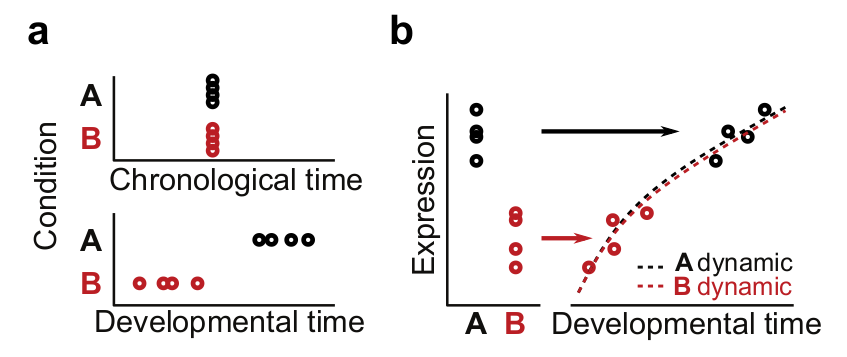

When sample groups have age differences but still overlap, the developmental effect can simply be accounted for by including age as a covariate in the Differential Expression (DE) analysis. If there is no age overlap however, it becomes impossible to know whether an observed effect is due to the perturbation or age since both variables are completely confounded.

Using `RAPToR` reference data, we can bridge the gap between non-overlapping sample groups and rescue otherwise impossible DE analyses.

# 2 Quickstart

## 2.1 Quantifying age-driven expression changes with `ref_compare()`

```r
# load libraries
library(RAPToR)
library(wormRef)
```

Given transcript per million (TPM) expression profiles from 3 control and 3 mutant samples.

```r
head(qs$tpm)
```

```
#>                    ctr1     ctr2     ctr3     mut1     mut2     mut3
#> WBGene00000001 2.862195 3.118323 3.175077 3.340883 3.426089 3.546783
#> WBGene00000002 3.107584 2.579527 2.156750 1.783193 1.843059 1.780094
#> WBGene00000003 2.586109 3.101123 3.152630 3.335000 3.244302 2.833467
#> WBGene00000004 1.930230 1.801899 1.706351 1.938189 2.018981 2.191545
#> WBGene00000005 2.866435 2.483658 2.125052 2.360653 2.545615 2.647073
#> WBGene00000006 1.583126 1.693566 1.873643 2.296500 2.266956 2.017384
```

```r
print(qs$pdat)
```

```
#>   sname strain
#> 1  ctr1    ctr
#> 2  ctr2    ctr
#> 3  ctr3    ctr
#> 4  mut1    mut
#> 5  mut2    mut
#> 6  mut3    mut
```

First, infer sample age with RAPToR.

```r
# load reference
r_cel <- prepare_refdata("Cel_larv_YA", "wormRef", 600)

# estimate sample age
ae_qs <- ae(qs$tpm, r_cel)
```

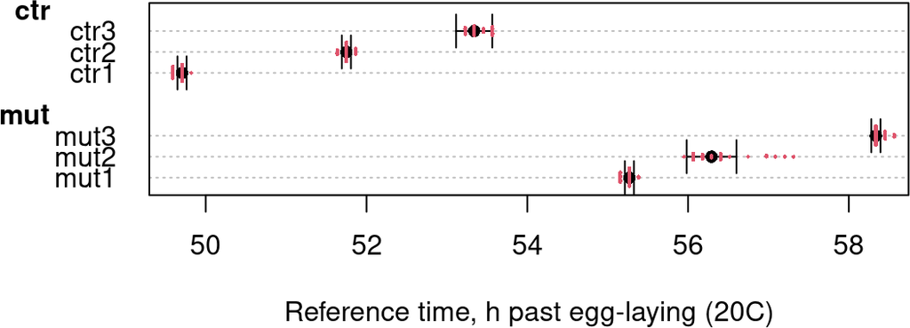

```r
plot(ae_qs, group = qs$pdat$strain, g.line=3, lmar=5)
```

Run `ref_compare()` to estimate developmental expression changes between groups.

```r
qs_rc <- ref_compare(
    X      = qs$tpm,        # sample data, log(TPM+1)
    ref    = r_cel,         # ref object
    ae_obj = ae_qs,         # ae object
    group  = qs$pdat$strain # factor defining compared groups (wt/mut)
)
```

Plot sample log2 fold-changes (logFCs) vs. expected developmental logFCs inferred from the reference.

```r
qs_lfc <- get_logFC(qs_rc)
```

```
#> Comparing ctr vs. mut
```

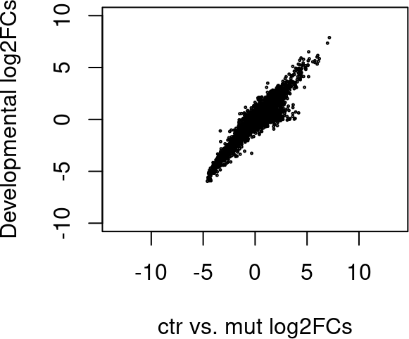

```r
plot(qs_lfc, cex=.2, asp=1,
     xlab = "ctr vs. mut log2FCs", xlim = c(-10,10),
     ylab = "Developmental log2FCs", ylim = c(-10, 10))
```

Print the correlation between sample and reference logFCs, as well as the average age difference between groups.

```r
print(qs_rc)
```

```
#> DE comparison with reference
#> ---
#>                 ref.logFC.r ref.logFC.r2 ae.avg.dif
#> ctr (ctrl, n=3)          NA           NA         NA
#> mut (n=3)             0.868        0.753      5.035
#> ---
```

In this example, ctr *vs.* mut logFCs have a correlation of $0.868$ with the expected developmental logFCs computed from the reference data. Using $r^2$, this corresponds to approximately $75.3 \%$ of variance explained by development. Such a large developmental effect between the control and mutant groups is expected as they don’t have any age overlap.

For an explanation of the analysis, see *How it works*.

A custom `ggplot` function to plot logFCs is also provided in *Plotting functions*, below.

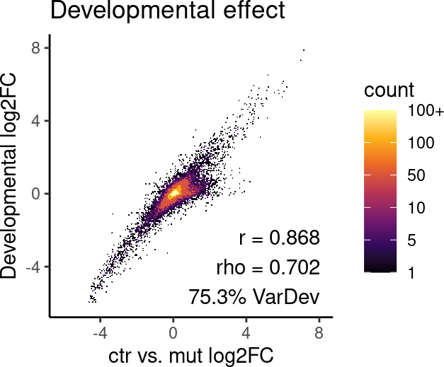

```r
gg_logFC(qs_lfc, main = "Developmental effect",
         xlab = "ctr vs. mut log2FC", ylab = "Developmental log2FC")
```